# xwMOOC 자동차

자동차 연비

xwMOOC

2017-12-25

## 1. 차량 연료 경제성 [^1] [^2] [^3]

자동차 연료의 효율성을 측정하는 지표로 영미권(영국, 미국, 캐나다)에서는 US 갤런과 Imperial 갤런을 사용하고 통상 MPG(Miles Per Gallon)로 표기합니다. 우리나라에서는 $km/l$ 단위를 사용하고, 대부분의 유럽, 아시아, 아프리카 오스트리아, 뉴질랜드 국가에서 $L/100 km$ 단위를 사용합니다.

US 갤런을 $km/l$로 변환하면 미국에서 시판되는 자동차에 대한 연비를 한국과 간접적으로 비교할 수가 있습니다.

## 2. 자동차 연비 비교

### 2.1. 환경설정 및 데이터 가져오기

[Download Fuel Economy Data](https://www.fueleconomy.gov/feg/download.shtml) 웹사이트에서 미국에서 시판중인 자동차 연비데이터를 다운로드 받아 분석에 활용한다.

```r
# 0. 환경설정 ------------------
library(tidyverse)
library(lubridate)
library(stringr)
library(ggridges)
library(ggpubr)
library(extrafont)
loadfonts()

# 1. 데이터 가져오기 환경설정 -------------------------

if (!file.exists("data/vehicles.csv")) {
  tmp <- tempfile(fileext = ".zip")
  download.file("http://www.fueleconomy.gov/feg/epadata/vehicles.csv.zip", tmp, quiet = TRUE)
  unzip(tmp, exdir = "data")
}

vehicles_dat <- read_csv("data/vehicles.csv")

vehicles_df <- vehicles_dat %>%
  tbl_df() %>%
  select(id, maker=make, model, year, class = VClass, trans = trany, drive = drive,
         cyl = cylinders, displ = displ, fuel = fuelType, hwy = highway08,
         cty = city08, co2 = co2TailpipeGpm) %>%
  filter(drive != "") %>%
  arrange(maker, model, year)
```

### 2.2. 데이터 전처리

자동차 연료유형, 차동차 유형(class), 변속기 등을 재정의하고, MPG를 `km/l`로 변환한다. [위키 단위 변환](https://en.wikipedia.org/wiki/Fuel_economy_in_automobiles#Unit_conversions)을 참고했다.

- 1 MPG $\approx$ 0.425 km/L

```r
# 2. 데이터 정제  ------------------
## 2.1. 범주형 데이터 범주 반영 -----------
vehicles_df <- vehicles_df %>% mutate(fuel_type = case_when(
  str_detect(fuel, "Gasoline|Midgrade") ~ "Gasoline",
  str_detect(fuel, "Premium") ~ "Premium",
  str_detect(fuel, "Regular") ~ "Regular",
  str_detect(fuel, "Diesel") ~ "Diesel",
  str_detect(fuel, "CNG") ~ "CNG",
  str_detect(fuel, "Electricity") ~ "Electricity"
)) %>% mutate(vclass = case_when(
  str_detect(class, "[S|s]mall") ~ "Small Cars",
  str_detect(class, "[M|m]idsize") ~ "Midsize Cars",
  str_detect(class, "[L|l]arge") ~ "Large Cars",
  str_detect(class, "[T|t]ruck") ~ "Pickup Trucks",
  str_detect(class, "[S|s]pecial Purpose") ~ "Special Purpose",
  str_detect(class, "[S|s]port Utility") ~ "SUV",
  str_detect(class, "[V|v]an") ~ "Vans & Minivans",
  TRUE ~ class
)) %>%
  mutate(trans = ifelse(str_detect(trans, "Auto"), "Automatic", "Manual")) %>%
  mutate(drive = case_when(
    str_detect(drive, "All-Wheel Drive") ~ "All-Wheel Drive",
    str_detect(drive, "Part-time 4-Wheel Drive") ~ "4-Wheel Drive",
    TRUE ~ drive
  )) %>%
    mutate(hwy_l = hwy * 0.425,
           cty_l = cty * 0.425) %>%  # MPG --> km/l 변환 -----------
  select(maker, model, year, vclass, trans, drive, cyl, displ, fuel_type, hwy, cty, hwy_l, cty_l, co2)

vehicles_df %>%
  filter(maker %in% c("GMC", "BMW","Nissan", "Ford", "Honda", "Hyundai", "Kia", "Toyota", "Volkswagen")) %>%
  DT::datatable()
```

|  | maker | model | year | vclass | trans | drive | cyl | displ | fuel_type | hwy | cty | hwy_l | cty_l | co2 |
| --- | --- | --- | --- | --- | --- | --- | --- | --- | --- | --- | --- | --- | --- | --- |
| 1 | BMW | 128ci Convertible | 2010 | Subcompact Cars | Automatic | Rear-Wheel Drive | 6 | 3 | Premium | 27 | 18 | 11.475 | 7.65 | 423.190476190476 |
| 2 | BMW | 128ci Convertible | 2010 | Subcompact Cars | Manual | Rear-Wheel Drive | 6 | 3 | Premium | 28 | 18 | 11.9 | 7.65 | 403.954545454545 |
| 3 | BMW | 128ci Convertible | 2011 | Subcompact Cars | Manual | Rear-Wheel Drive | 6 | 3 | Premium | 28 | 19 | 11.9 | 8.075 | 403.954545454545 |
| 4 | BMW | 128ci Convertible | 2011 | Subcompact Cars | Automatic | Rear-Wheel Drive | 6 | 3 | Premium | 26 | 18 | 11.05 | 7.65 | 423.190476190476 |
| 5 | BMW | 128ci Convertible | 2012 | Subcompact Cars | Automatic | Rear-Wheel Drive | 6 | 3 | Premium | 26 | 18 | 11.05 | 7.65 | 423.190476190476 |
| 6 | BMW | 128ci Convertible | 2012 | Subcompact Cars | Manual | Rear-Wheel Drive | 6 | 3 | Premium | 27 | 18 | 11.475 | 7.65 | 403.954545454545 |
| 7 | BMW | 128ci Convertible | 2013 | Subcompact Cars | Automatic | Rear-Wheel Drive | 6 | 3 | Premium | 26 | 18 | 11.05 | 7.65 | 427 |
| 8 | BMW | 128ci Convertible | 2013 | Subcompact Cars | Manual | Rear-Wheel Drive | 6 | 3 | Premium | 28 | 19 | 11.9 | 8.075 | 407 |
| 9 | BMW | 128i | 2008 | Subcompact Cars | Manual | Rear-Wheel Drive | 6 | 3 | Premium | 28 | 18 | 11.9 | 7.65 | 423.190476190476 |
| 10 | BMW | 128i | 2008 | Subcompact Cars | Automatic | Rear-Wheel Drive | 6 | 3 | Premium | 28 | 19 | 11.9 | 8.075 | 403.954545454545 |

[output cut: 13970 more lines]

## 3. 자동차 연비 시각화

### 3.1. 연도별 자동차 연비변화

모든 제조사에 대해서 연비변화를 추적해보는 것보다 주요 자동차 제조사를 미국, 일본, 유럽, 한국에서 선정하여 연도별 연비변화를 추적해 보자.

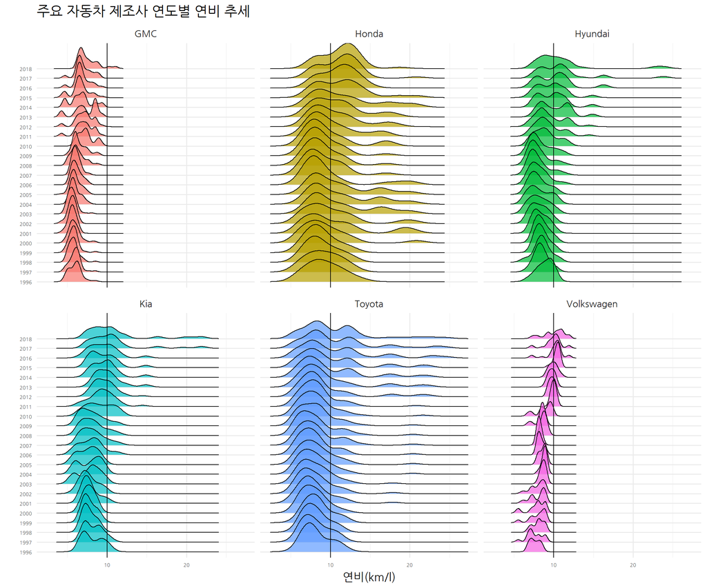

```r
# 3. 연비 시각화 -----------
## 3.0. 주요 자동차 제조사 -----------
major_maker <- c("GMC", "Honda", "Hyundai", "Kia", "Toyota", "Volkswagen")

fuel_df <- vehicles_df %>%
  filter(maker %in% major_maker)

## 3.1. 연도별 연비 변화
fuel_df %>%
  filter(fuel_type %in% c("Regular")) %>%
  filter(year > 1995) %>%
  ggplot(aes(x = cty_l, y = factor(year), fill=maker)) +
    geom_density_ridges(scale = 3, alpha=0.7) +
    theme_minimal(base_size = 14, base_family = "NanumGothic") +
    theme(legend.position = "none",
          axis.text=element_text(size=6)) +
    labs(x="연비(km/l)", y="", title="주요 자동차 제조사 연도별 연비 추세") +
    guides(fill = guide_legend(nrow = 1)) +
    facet_wrap(~maker) +
    geom_vline(xintercept = 10)
```

### 3.2. 자동차 유형별

SUV, 소형, 중형 등 자동차 유형별 연비차이를 한국, 일본, 독일 대표 제조사를 대상으로 살펴보자.

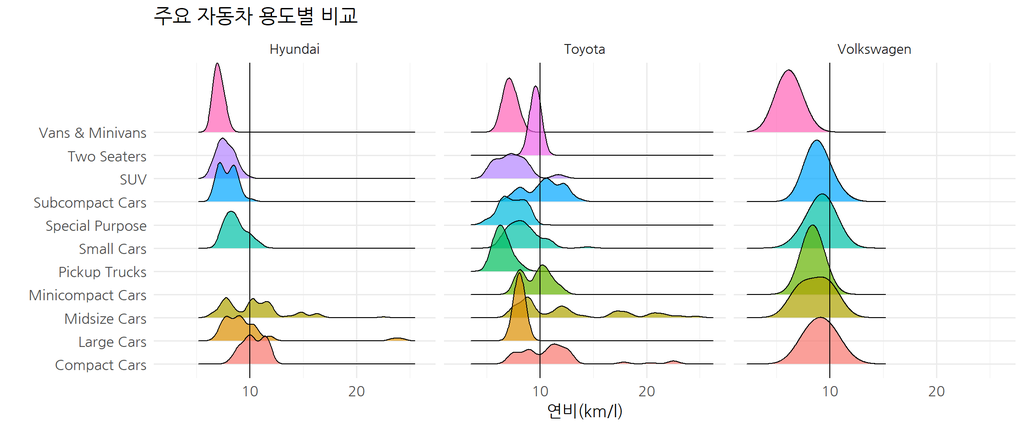

```r
## 3.2. 자동차 용도별 --------------
fuel_df %>%
  filter(fuel_type %in% c("Regular")) %>%
  filter(year > 1995) %>%
  filter(str_detect(maker, "Hyundai|Toyota|Volkswagen")) %>%
  ggplot(aes(x = cty_l, y = vclass, fill=vclass)) +
  geom_density_ridges(scale = 3, alpha=0.7) +
  theme_minimal(base_size = 14, base_family = "NanumGothic") +
  theme(legend.position = "none",
        axis.text=element_text(size=12)) +
  labs(x="연비(km/l)", y="", title="주요 자동차 용도별 비교") +
  guides(fill = guide_legend(nrow = 1)) +
  facet_wrap(~maker, ncol=3) +
  geom_vline(xintercept = 10)
```

### 3.3. 자동차 엔진 실린더 갯수

자동차 엔진 실린더 갯수별로 연비차이를 제조사와 비교하여 확인해 보자.

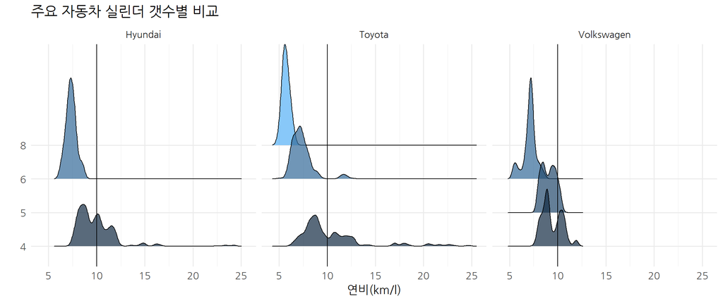

```r
## 3.3. 자동차 실린더 갯수 --------------
fuel_df %>%
  filter(fuel_type %in% c("Regular")) %>%
  filter(year > 1995) %>%
  filter(str_detect(maker, "Hyundai|Toyota|Volkswagen")) %>%
  ggplot(aes(x = cty_l, y = factor(cyl), fill=cyl)) +
  geom_density_ridges(scale = 3, alpha=0.7) +
  theme_minimal(base_size = 14, base_family = "NanumGothic") +
  theme(legend.position = "none",
        axis.text=element_text(size=12)) +
  labs(x="연비(km/l)", y="", title="주요 자동차 실린더 갯수별 비교") +
  guides(fill = guide_legend(nrow = 1)) +
  facet_wrap(~maker, ncol=3) +
  geom_vline(xintercept = 10)
```

### 3.4. 자동차 엔진 배기량

엔진 배기량에 따라 연비변화도 살펴보자.

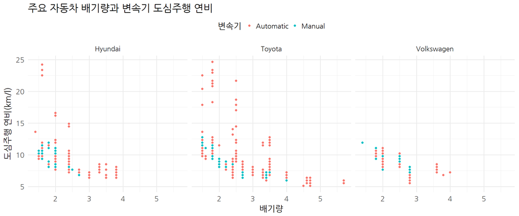

```r
## 3.4. 배기량과 변속기 --------------
fuel_df %>%
  filter(fuel_type %in% c("Regular")) %>%
  filter(year > 1995) %>%
  filter(str_detect(maker, "Hyundai|Toyota|Volkswagen")) %>%
  ggplot(aes(x=displ, y=cty_l, color=trans)) +
    geom_point() +
    facet_wrap(~maker) +
  theme_minimal(base_size = 14, base_family = "NanumGothic") +
  theme(legend.position = "top",
        axis.text=element_text(size=12)) +
  labs(y="도심주행 연비(km/l)", x="배기량", title="주요 자동차 배기량과 변속기 도심주행 연비",
       color="변속기")
```

### 3.5. 도심주행과 고속도로 주행 연비

도심주행과 고속도로 주행 연비에 대해서도 비교해보자.

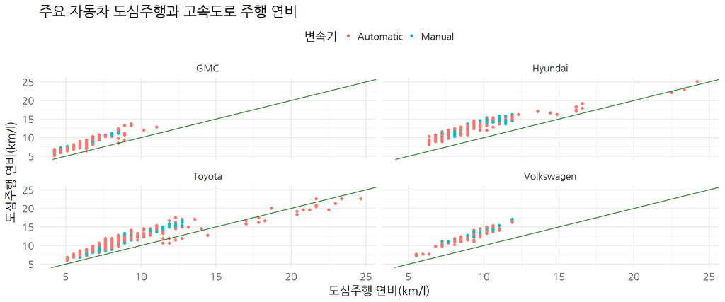

```r
## 3.5. 자동차 도심주행과 고속도로 주행 --------------
fuel_df %>%
  filter(fuel_type %in% c("Regular")) %>%
  filter(year > 1995) %>%
  filter(str_detect(maker, "Hyundai|Toyota|Volkswagen|GMC")) %>%
  ggplot(aes(x=cty_l, y=hwy_l, color=trans)) +
  geom_point() +
  facet_wrap(~maker) +
  geom_abline(intercept = 0, slope=1, color = "darkgreen") +
  theme_minimal(base_size = 14, base_family = "NanumGothic") +
  theme(legend.position = "top",
        axis.text=element_text(size=12)) +
  labs(x="도심주행 연비(km/l)", y="도심주행 연비(km/l)", title="주요 자동차 도심주행과 고속도로 주행 연비",
       color="변속기")
```

### 3.6. 도심주행연비와 이산화탄소 배출량

도심주행연비와 이산화탄소 배출량을 GM과 현대차를 비교해보자.

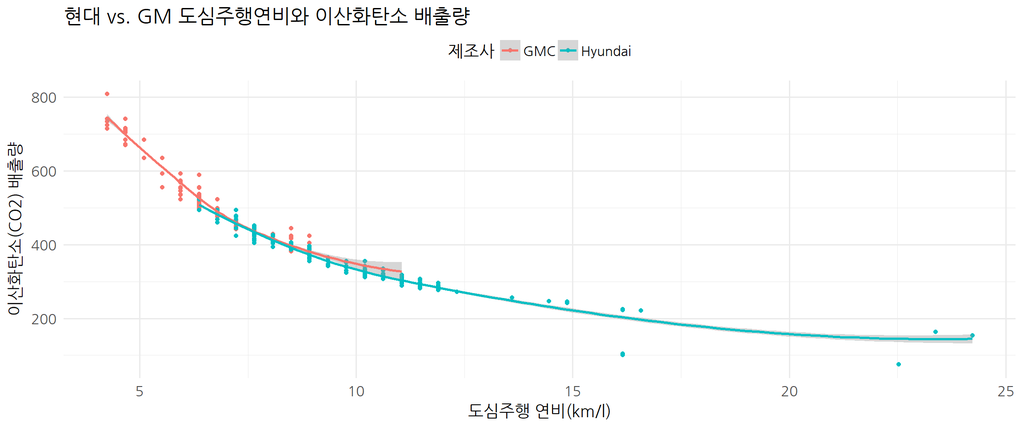

```r
## 3.6. 자동차 도심주행연비와 CO2 배출량 --------------
fuel_df %>%
  filter(fuel_type %in% c("Regular")) %>%
  filter(year > 1995) %>%
  filter(str_detect(maker, "Hyundai|GMC")) %>%
  ggplot(aes(x=cty_l, y=co2, color=maker)) +
  geom_point() +
  stat_smooth() +
  # facet_wrap(~maker) +
  theme_minimal(base_size = 14, base_family = "NanumGothic") +
  theme(legend.position = "top",
        axis.text=element_text(size=12)) +
  labs(x="도심주행 연비(km/l)", y="이산화탄소(CO2) 배출량", title="현대 vs. GM 도심주행연비와 이산화탄소 배출량",
       color="제조사")
```

### 3.7. 현대자동차 유형별 연비변화

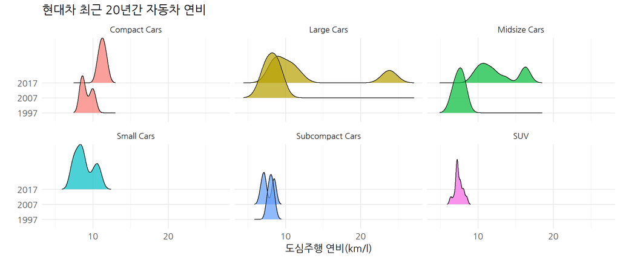

```r
## 3.7. 현대자동차 연비 --------------
## 3.7. 현대자동차 연비 --------------
fuel_df %>%
  filter(fuel_type %in% c("Regular")) %>%
  filter(year %in% c(2017, 2007, 1997)) %>%
  filter(str_detect(maker, "Hyundai")) %>%
  filter(vclass != "Vans & Minivans") %>%
  ggplot(aes(x=cty_l, y=factor(year), fill=factor(vclass))) +
  geom_density_ridges(scale = 3, alpha=0.7) +
  facet_wrap(~vclass) +
  theme_minimal(base_size = 14, base_family = "NanumGothic") +
  theme(legend.position = "none",
        axis.text=element_text(size=12)) +
  labs(x="도심주행 연비(km/l)", y="", title="현대차 최근 20년간 자동차 연비", color="")
```

[^1]: [Data Exploration with Python, Part 2, “Preparing Your Data to be Explored”, Tony Ojeda](http://blog.districtdatalabs.com/data-exploration-with-python-2)
[^2]: [위키백과 - Fuel economy in automobiles](https://en.wikipedia.org/wiki/Fuel_economy_in_automobiles#Unit_conversions)
[^3]: [How to Access Any RESTful API Using the R Language](https://www.programmableweb.com/news/how-to-access-any-restful-api-using-r-language/how-to/2017/07/21)